# CO2 Redesign: Chart Alternatives

Testing bump chart and connected dot plot against the current faceted bar chart

## Why test alternatives

The current main chart (`co2_redesign.qmd`) uses a faceted bar chart: one ranked bar panel per metric. It is easy to read exact values, but it breaks the thing the original Reuters ribbon chart did well — letting a reader watch one country’s position shift as the metric changes. This page builds two alternatives that keep that “story” while fixing the original’s real problems (uncontrolled flow widths, dense crossings, unreadable rotated labels for small countries).

```r
library(tidyverse)

plot_data <- read_csv("../data/cleaned/co2_metric_comparison_long.csv", show_col_types = FALSE)

metric_levels <- c(
  "Annual territorial CO2",
  "Cumulative territorial CO2",
  "Territorial CO2 per capita",
  "Consumption CO2 per capita"
)

plot_data <- plot_data |>
  mutate(metric = factor(metric, levels = metric_levels))

country_palette <- c(
  "China" = "#E69F00",
  "United States" = "#56B4E9",
  "India" = "#009E73",
  "European Union (27)" = "#F0E442",
  "Russia" = "#0072B2",
  "Japan" = "#D55E00",
  "Germany" = "#CC79A7",
  "United Kingdom" = "#999999",
  "Singapore" = "#882255"
)

# Countries to highlight in color; everyone else fades to gray context lines.
highlight_countries <- c("China", "United States", "India", "Singapore")

plot_data <- plot_data |>
  mutate(
    highlight = country %in% highlight_countries,
    line_color = if_else(highlight, country, "Other")
  )

highlight_palette <- c(country_palette[highlight_countries], "Other" = "#cccccc")
```

## Option 1: Bump chart

Rank (not raw value) on the y-axis, metric on the x-axis, one line per country. This is the most direct structural replacement for the original ribbon chart’s “rank-flow” story.

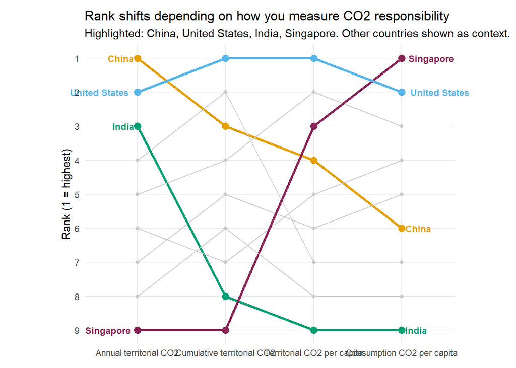

```r
bump_chart <- ggplot(
  plot_data,
  aes(x = metric, y = rank, group = country, color = line_color)
) +
  geom_line(aes(linewidth = highlight), lineend = "round") +
  geom_point(aes(size = highlight)) +
  geom_text(
    data = filter(plot_data, metric == first(metric_levels), highlight),
    aes(label = country),
    hjust = 1.15, size = 3.2, fontface = "bold"
  ) +
  geom_text(
    data = filter(plot_data, metric == last(metric_levels), highlight),
    aes(label = country),
    hjust = -0.15, size = 3.2, fontface = "bold"
  ) +
  scale_y_reverse(breaks = 1:9) +
  scale_color_manual(values = highlight_palette, guide = "none") +
  scale_linewidth_manual(values = c(`TRUE` = 1.1, `FALSE` = 0.5), guide = "none") +
  scale_size_manual(values = c(`TRUE` = 3, `FALSE` = 1.5), guide = "none") +
  labs(
    title = "Rank shifts depending on how you measure CO2 responsibility",
    subtitle = "Highlighted: China, United States, India, Singapore. Other countries shown as context.",
    x = NULL, y = "Rank (1 = highest)"
  ) +
  theme_minimal(base_size = 11) +
  theme(
    panel.grid.minor = element_blank(),
    plot.margin = margin(10, 60, 10, 60)
  ) +
  coord_cartesian(clip = "off")

bump_chart
```

```r
ggsave("bump_chart.png", bump_chart, width = 10, height = 6, dpi = 300)
```

## Option 2: Connected dot plot

Countries as rows, one dot per metric, rank shown as the label inside each dot, dots in a row connected by a thin line. Less dramatic than the bump chart’s crossing lines, but easier to scan per country.

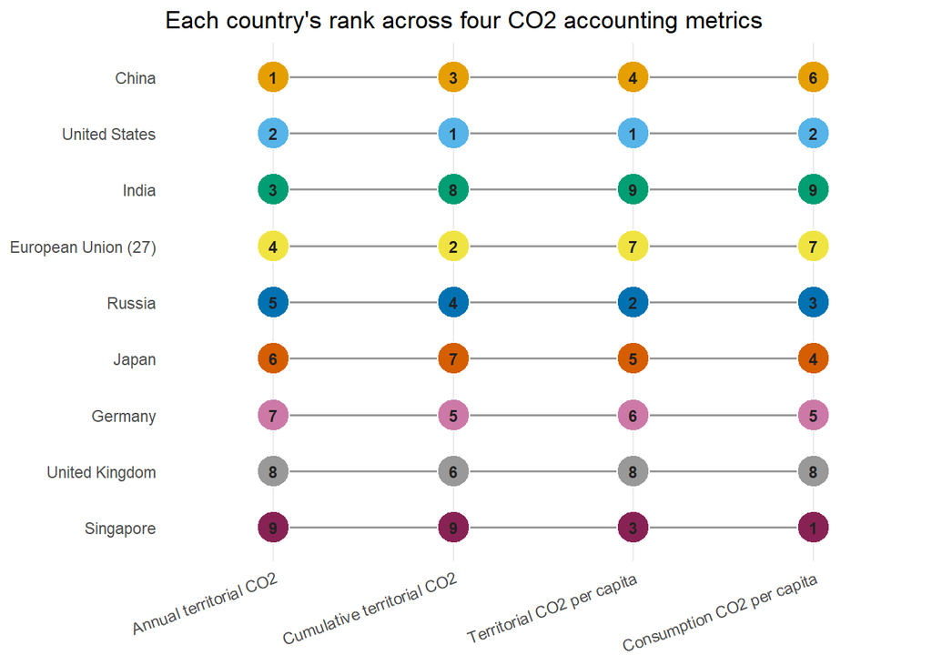

```r
country_order <- plot_data |>
  filter(metric == "Annual territorial CO2") |>
  arrange(rank) |>
  pull(country)

dot_data <- plot_data |>
  mutate(country = factor(country, levels = rev(country_order)))

connected_dot_plot <- ggplot(dot_data, aes(x = metric, y = country, group = country)) +
  geom_line(color = "#999999", linewidth = 0.6) +
  geom_point(aes(fill = country), shape = 21, size = 8, color = "white", stroke = 0.6) +
  geom_text(aes(label = rank), size = 3, fontface = "bold", color = "#222222") +
  scale_fill_manual(values = country_palette, guide = "none") +
  labs(
    title = "Each country's rank across four CO2 accounting metrics",
    x = NULL, y = NULL
  ) +
  theme_minimal(base_size = 11) +
  theme(
    panel.grid.major.y = element_blank(),
    axis.text.x = element_text(angle = 20, hjust = 1)
  )

connected_dot_plot
```

```r
ggsave("connected_dot_plot.png", connected_dot_plot, width = 10, height = 6, dpi = 300)
```

## Discussion notes for the team

- **Bump chart**: closest structural match to the brief (“translate from perspective to perspective easily”) and to what the professor described. With 9 countries, full-color lines get crowded — used highlight + gray context here. Decide as a team whether 4 highlighted countries is the right number, or whether it should track the same comparison set as the main chart.
- **Connected dot plot**: compact, shows the exact rank number without needing to read position on a y-axis, but loses the “crossing lines = the story” visual impact that sold the original chart’s narrative.
- **Faceted bar chart (existing, not reproduced here)**: still the best option if precise values matter more than rank-flow storytelling — worth keeping as a secondary panel either way, even if the primary chart changes.